# hw2

dislosure fan

По адресу https://raw.githubusercontent.com/SergeyMirvoda/da2016/master/data/calif_penn_2011.csv можно получить набор данных, содержащий информацию о домовладениях в Калифорнии и Пенсильвании за 2011г. Информация сгруппированна по зонам переписи (Census tracts).

h2. Загрузка и очистка данных

- Загрузите данные в датафрейм, который назовите data.

```r
data <- read.csv('https://raw.githubusercontent.com/SergeyMirvoda/da2016/master/data/calif_penn_2011.csv');
```

- Сколько строк и столбцов в data?

```r
nrow(data); #11275 строк
```

```
## [1] 11275
```

```r
ncol(data); #34 столбца
```

```
## [1] 34
```

- Выполните следующую команду и объясните, что она делает. colSums(apply(data,c(1,2), is.na))

```r
colSums(apply(data,c(1,2), is.na))
```

```
##                           X                     GEO.id2
##                           0                           0
##                     STATEFP                    COUNTYFP
##                           0                           0
##                     TRACTCE                  POPULATION
##                           0                           0
##                    LATITUDE                   LONGITUDE
##                           0                           0
##           GEO.display.label          Median_house_value
##                           0                         599
##                 Total_units                Vacant_units
##                           0                           0
##                Median_rooms  Mean_household_size_owners
##                         157                         215
## Mean_household_size_renters         Built_2005_or_later
##                         152                          98
##          Built_2000_to_2004                 Built_1990s
##                          98                          98
##                 Built_1980s                 Built_1970s
##                          98                          98
##                 Built_1960s                 Built_1950s
##                          98                          98
##                 Built_1940s       Built_1939_or_earlier
##                          98                          98
##                  Bedrooms_0                  Bedrooms_1
##                          98                          98
##                  Bedrooms_2                  Bedrooms_3
##                          98                          98
##                  Bedrooms_4          Bedrooms_5_or_more
##                          98                          98
##                      Owners                     Renters
##                         100                         100
##     Median_household_income       Mean_household_income
##                         115                         126
```

Выполнение данной команды выводит количество значений NA (missing values - отсутствующие значения) или не заполенных строчек отдельно для каждой из колонок. Например, для Mean_household_income значение не заполнено в 126 строчках - http://prntscr.com/l2psz9.

- Функция na.omit() принимает датафрейм и возвращает новый датафрейм, игнорируя строки, содержащие значение NA. Используйте эту функцию для удаления строк с неполными данными.

```r
notNAdata <- na.omit(data)
```

- Сколько строк было удалено?

```r
nrow(data) - nrow(notNAdata)
```

```
## [1] 670
```

Было удалено 670 строк.

- Соответствует ли результат выполнения, значениям из пункта 3?

Нет ни одной колонки, для которой бы выполнение команды из п. 3 дало бы результат, бОльший 670 строк. Следовательно, можно утверждать, что удаление строк с пустыми значениями в некоторых колонках прошло успешно с учетом того, что в разных строках отсутствовали значения из разных колонок.

h2. Новые дома

- Переменная(колонка) Built_2005_or_later содержит данные о проценте домов, построенных с 2005 года. Постройте диаграмму рассеяния (scatterplot) медианы стоимости домов (переменная Median_house_value) относительно процента новых домов.

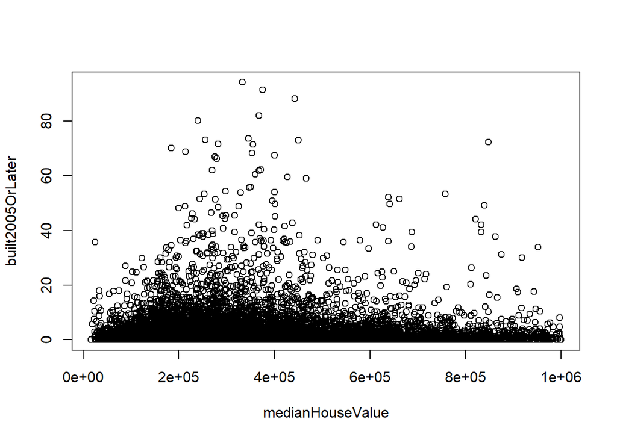

```r
built2005OrLater <- notNAdata$Built_2005_or_later
medianHouseValue <- notNAdata$Median_house_value
plot(built2005OrLater ~ medianHouseValue)
```

- Постройте ещё два графика для каждого из штатов отдельно. Номер штата содержится в переменной (STATEFP), где Калифорния 6-й штат, а Пенсильвания 42.

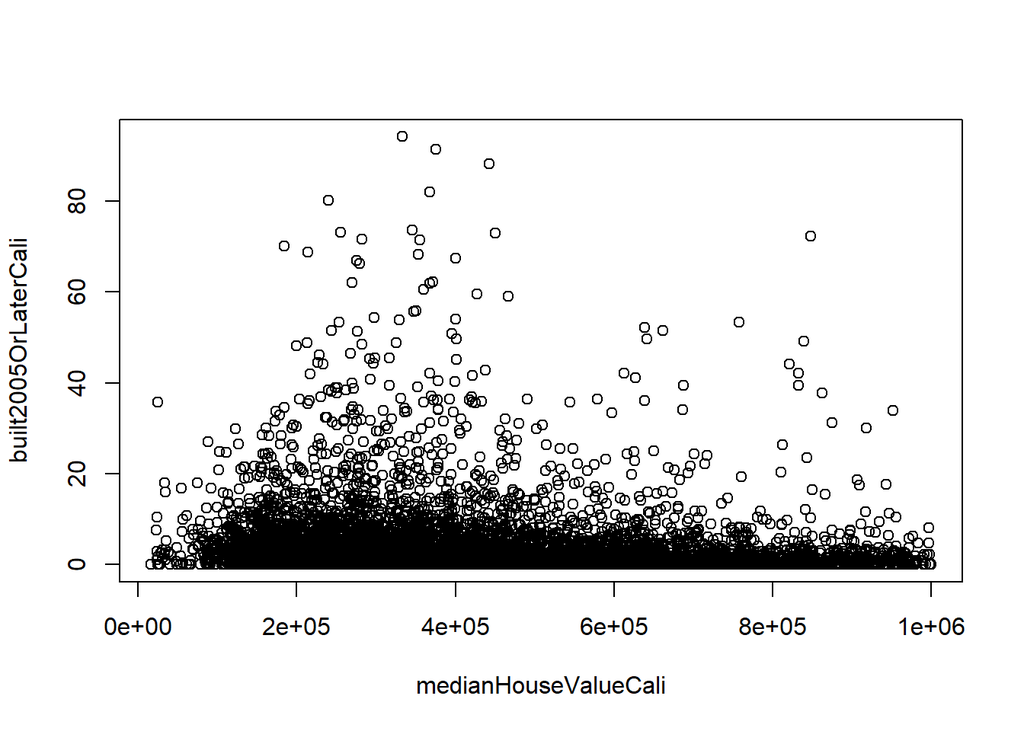

```r
# Калифорния

built2005OrLaterCali <- notNAdata$Built_2005_or_later[notNAdata$STATEFP == 6]
medianHouseValueCali <- notNAdata$Median_house_value[notNAdata$STATEFP == 6]
plot(built2005OrLaterCali ~ medianHouseValueCali)
```

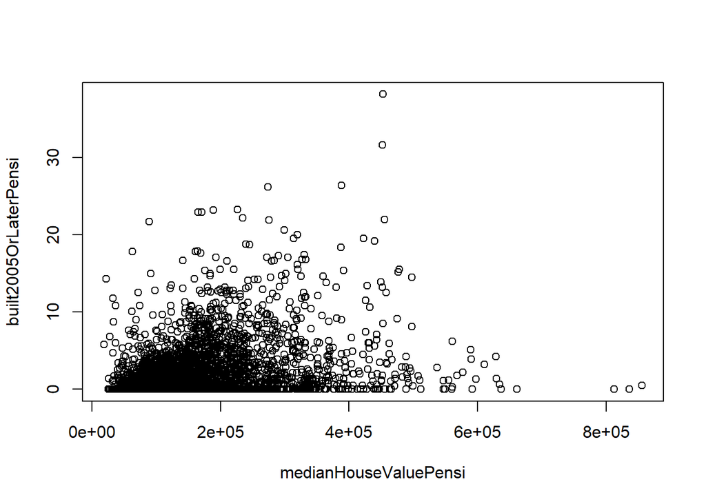

```r
#Пенсильвания

built2005OrLaterPensi <- notNAdata$Built_2005_or_later[notNAdata$STATEFP == 42]
medianHouseValuePensi <- notNAdata$Median_house_value[notNAdata$STATEFP == 42]
plot(built2005OrLaterPensi ~ medianHouseValuePensi)
```

h2. Незанятые дома

Уровень найма (vacancy rate) — доля домов, которые не были заняты. В данных содержатся колонки, содержащие общее количество домовладений и количество не занятых домовладений.

- В датафрейм data добавьте новую колонку vacancy_rate, которая должна содержать вышеописанный показатель

```r
notNAdata['vacancy_rate'] = notNAdata$Vacant_units/notNAdata$Total_units
```

- Найдите минимум, максимум, среднее и медиану полученных значений показателя.

```r
vacancy_rate = notNAdata$vacancy_rate
min(vacancy_rate)
```

```
## [1] 0
```

```r
max(vacancy_rate)
```

```
## [1] 0.965311
```

```r
mean(vacancy_rate)
```

```
## [1] 0.08888789
```

```r
median(vacancy_rate)
```

```
## [1] 0.06767283
```

- Постройте диаграмму уровня найма относительно медианы стоимости домов. Что можно заметить?

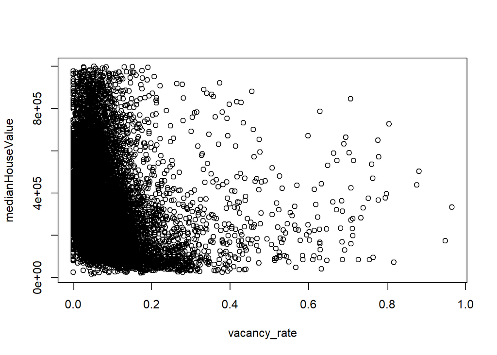

```r
plot(medianHouseValue ~ vacancy_rate)
```

Можно заметить, что при меньшей стоимости дома процент незанятости выше (т.е. у них обратная зависимость).

h2. Корреляция

Колонка COUNTYFP содержит числовой код округа внутри штата. Нас интересуют Butte County (округ 7 в Калифорнии), Santa Clara (округ 85 в Калифорнии) и York County (округ 133 в Пенсильвании).

- Объясните, что делает приведённый в конце задания код и как именно он это делает.

Объяснил в комментариях к коду (там еще надо было поменять ca_pa на ту переменную, в которой у меня хранятся данные без NA - notNAdata).

```r
# создаем пустую переменную, типа var arr = []
acc <- c()

for (tract in 1:nrow(notNAdata)) {
  if (notNAdata$STATEFP[tract] == 6) {
    if (notNAdata$COUNTYFP[tract] == 1) {
      #tract - это номер строчки. Если в tract-строчке STATEFP==6 (т.е. Калифорния), а в COUNTYFP == 1 (ALAMEDA), то номер данной строчки записывается в массив acc
      acc <- c(acc, tract)
    }
  }
}
accmv <- c()
# Запомнили номера строчек, соответствующих нужному нам округу, теперь для каждой строчки записываем в вектор accmv значение Median_house_value, т.е. стоимость дома, видимо, в долларах США
for (tract in acc) {
  accmv <- c(accmv, notNAdata[tract,10])
}
# Ну и считаем медианную стоимость дома в данном округе - ALAMEDA CALIFORNIA
median(accmv)
```

```
## [1] 474050
```

```r
# Получается 474050 долларов США
```

- Напишите другим способом в одну строку, то же самое, что делает нижеуказанный код. Способов получить тот же ответ множество, достаточно одного.

```r
# В одну строчку, значение получается то же
medianHouseValueAlameda <- median(notNAdata$Median_house_value[notNAdata$STATEFP == 6][notNAdata$COUNTYFP == 1],  na.rm = TRUE)
```

- Найдите средний процент построенных домовладений в округах (Butte County, Santa Clara, York County)

Построено-то везде 100% домовладений, насколько я понимаю. Найдем процент тех, которые построены после 2005.

```r
meanHouseBuilt2005Butte <- mean(notNAdata$Built_2005_or_later[notNAdata$STATEFP == 6][notNAdata$COUNTYFP == 7],  na.rm = TRUE) # 4,7 в Butte
meanHouseBuilt2005SC <- mean(notNAdata$Built_2005_or_later[notNAdata$STATEFP == 6][notNAdata$COUNTYFP == 85],  na.rm = TRUE) # 3.2 в Santa Clara
meanHouseBuilt2005YC <- mean(notNAdata$Built_2005_or_later[notNAdata$STATEFP == 42][notNAdata$COUNTYFP == 133],  na.rm = TRUE) # Тут непонятно, нет домов, постороенных после 2005 в этом округе
```

- Функция cor рассчитывает коэффициент корреляции между двумя переменными. Рассчитайте корреляцию между медианы стоимости домовладений (Median_house_value) и процентом построенных домов (Built_2005_or_later):

```r
# для всего набора данных
cor(built2005OrLater, medianHouseValue)
```

```
## [1] -0.01893186
```

```r
#для Калифорнии
cor(built2005OrLaterCali, medianHouseValueCali)
```

```
## [1] -0.1153604
```

```r
# для Пенсильвании
cor(built2005OrLaterPensi, medianHouseValuePensi)
```

```
## [1] 0.2681654
```

```r
# для округа Butte County
cor(na.omit(notNAdata$Built_2005_or_later[notNAdata$STATEFP == 6][notNAdata$COUNTYFP == 7]), na.omit(notNAdata$Median_house_value[notNAdata$STATEFP == 6][notNAdata$COUNTYFP == 7]))
```

```
## [1] 0.04203267
```

```r
#для округа Santa Clara
cor(na.omit(notNAdata$Built_2005_or_later[notNAdata$STATEFP == 6][notNAdata$COUNTYFP == 85]), na.omit(notNAdata$Median_house_value[notNAdata$STATEFP == 6][notNAdata$COUNTYFP == 85]))
```

```
## [1] -0.1726203
```

```r
#для округа York County
cor(na.omit(notNAdata$Built_2005_or_later[notNAdata$STATEFP == 42][notNAdata$COUNTYFP == 133]), na.omit(notNAdata$Median_house_value[notNAdata$STATEFP == 42][notNAdata$COUNTYFP == 133]))
```

```
## [1] NA
```

- Постройте три диаграммы медианы стоимости домовладений (Median_house_value) относительно медианы дохода (Median_household_income) для трёх округов. Допустимо указать все три на одном графике.

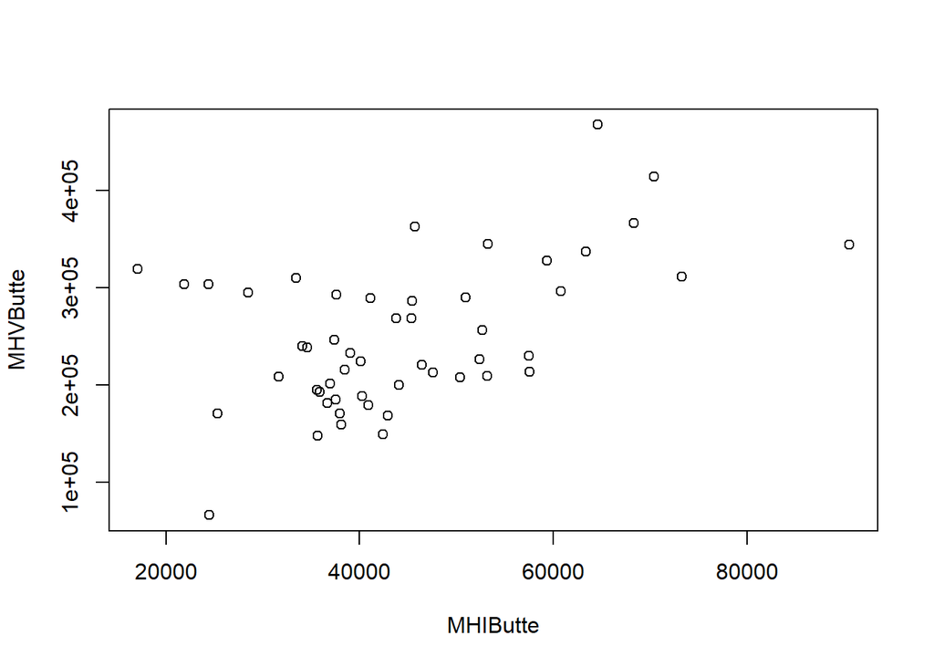

```r
MHVButte <- na.omit(notNAdata$Median_house_value[notNAdata$STATEFP == 6][notNAdata$COUNTYFP == 7])
MHIButte <- na.omit(notNAdata$Median_household_income[notNAdata$STATEFP == 6][notNAdata$COUNTYFP == 7])
plot(MHVButte ~ MHIButte) # для Butte
```

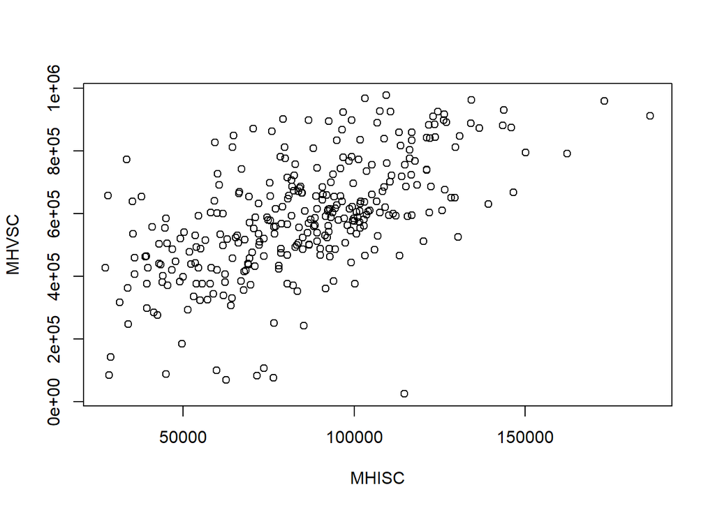

```r
MHVSC <- na.omit(notNAdata$Median_house_value[notNAdata$STATEFP == 6][notNAdata$COUNTYFP == 85])
MHISC <- na.omit(notNAdata$Median_household_income[notNAdata$STATEFP == 6][notNAdata$COUNTYFP == 85])
plot(MHVSC ~ MHISC) # для Santa Clara
```

```r
#plot(na.omit(notNAdata$Median_house_value[notNAdata$STATEFP == 42][notNAdata$COUNTYFP == 133]) ~ na.omit(notNAdata$Median_household_income[notNAdata$STATEFP == 42][notNAdata$COUNTYFP == 133]))
```